# Normal linear models

## Overview

> By the end of these workshops and your own studies, you should be able to
- Formally describe a statistical model
- Implement statistical models (continuous, categorical predictors)
- Interpret model coefficients and quantities related to null hypothesis testing (confidence interval, *t*-value, *p*-value)
- Conceptual understand how maximum likelihood estimation works (how `lm` determines model coefficients)
- Predict hypothetical outcomes given a statistical model (to visualise results, calculating residual error and therefore log-likelihood and model comparison)

Using a combination of theoretical descriptions, practical exercises, implementations, and simulations.

## Update your workshop repository

- Go to github.com/jensroes/stats-iii
- Download the repository
- Extract the `linear-models` and `model-comparison` folder
- Move these into last week’s directory

## Regression models

- Often introduced as fitting lines to points.
- Limited perspective that makes more complex regression models, like generalised linear models, hard to understand.
- Extension to generalised and multilevel linear models (multiple / simple linear regressions, AN(C)OVAs, MAN(C)OVAs)
- Backbone of statistical modelling: machine learning, time series models, path analysis, structural equation models, factor analysis, signal detection models

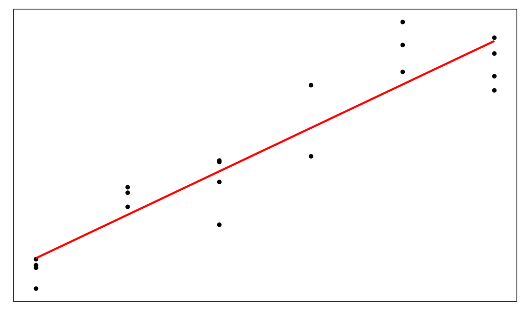

## Regression models

- A model of how the probability distribution of one variable, known as the *outcome variable*, varies as a function of other variables, known as the *explanatory* or *predictor variables*.
- The most basic type of regression models is the normal linear model.
- In normal linear models, we assume that the outcome variable is normally distributed and that its mean varies linearly with changes in a set of predictor variables.
- By understanding the normal linear model thoroughly, we can see how it can be extended to deal with data and problems beyond those that it is designed for.

## Normal linear model (formal description)

\[ \begin{aligned} y_i &\sim \mathcal{N}(\mu, \sigma^2) \end{aligned} \]

- \(y\): observed univariate *outcome* variable
- Each observation \(y_i\) is a sample from such a normal distribution (index by \(i\))
- “\(\sim\)”: “is proportional to” / “is a function of”
- \(\mathcal{N}\): univariate normal distributed probability model with mean \(\mu\) and variance \(\sigma^2\) (or standard deviation \(\sigma\))
- **Population parameters** are represented as Greek letters; i.e. what we want to know about our population given a set of assumptions about the nature of our data.

## Normal linear model (formal description)

\[ \begin{aligned} y_i &\sim \mathcal{N}(\mu_i, \sigma^2)\\ \mu_i &= \beta_0 + \beta_1 \cdot x_{1i} \\ \end{aligned} \]

Value of \(\mu_i\) is deterministic (“\(=\)”) linear function of values of predictor variables \(x\) for each observation \(i\) and the unknowns \(\beta_0\) (intercept) and \(\beta_1\) (slope):

- \(\beta_1\) directly depends on \(x_{1i}\)
- \(\beta_0\) is “constant”
- If \(x_{1i}\) takes on 0, \(\mu_i = \beta_0\)
- If \(x_{1i}\) takes on 1, \(\mu_i = \beta_0 + \beta_1\)
- Hence, \(\beta_1\) is the difference between \(x_{1i}=1\) and \(x_{1i}=0\): value we need to add to \(\beta_0\) when \(x_{1i}=1\) instead of \(x_{1i}=0\).

## Normal linear model (general form)

\[ \begin{aligned} y_i &\sim \mathcal{N}(\mu_i, \sigma^2)\\ \mu_i &= \beta_0 + \beta_1 \cdot x_{1i} + \beta_2 \cdot x_{2i} \dots \beta_k \cdot x_{ki} \dots \beta_K \cdot x_{Ki} \end{aligned} \]

## Normal linear model (general form)

\[ \begin{aligned} y_i &\sim \mathcal{N}(\mu_i, \sigma^2)\\ \mu_i &= \beta_0 + \beta_1 \cdot x_{1i} + \beta_2 \cdot x_{2i} \dots \beta_k \cdot x_{ki} \dots \beta_K \cdot x_{Ki}\\ & = \beta_0 + \sum_{k=1}^K \beta_k \cdot x_{ki}\\ \end{aligned} \]

- Introducing \(K\) in \(x_{Ki}\) allows us to abbreviate the model equation.
- Probabilistic model (i.e. “\(\sim\)”) of \(y_1 \dots y_n\) conditional on \(\overrightarrow{x_1}\dots\overrightarrow{x_n}\), \(\overrightarrow{\beta} = \beta_0, \beta_1\dots\beta_K\), and \(\sigma\)
- \(K\) values used to explain \(y_i\). \(\overrightarrow{x_i}\) are a set of \(K\) *explanatory* variables.
- Which ones do we know and which ones must be inferred?

## Normal linear model (example)

> A model of how the mean of the distribution of reaction time values (rt) varies as a function of age and sex.

\[ \begin{align} \text{rt}_i &\sim \mathcal{N}(\mu_i, \sigma^2)\\ \mu_i &= \beta_0 + \beta_\text{age} \cdot \text{age}_i + \beta_\text{sex} \cdot \text{sex}_i \end{align} \]

> For \(i \in 1\dots n\) where \(n\) is total number of observations.
- Writing down (on paper) a formal model description for an hypothetical normal linear model of blood pressure as a function of / predicted by nutrition, age, and levels of physical activity.
- We will then write down the model description in RMarkdown.

## Simulation of normal distributed data

- We can use `lm` to easily implement such a model.

```r
model <- lm(rt ~ age + sex, data = data)
```

- How do we know that `lm` returns accurate estimates for our model parameters?
- We can simulate data that exactly meet model assumptions (normal distribution, equal variance, independence etc.) with known model parameters.

## Simulation of normal distributed data

- `rnorm` generates unimodal, symmetrically distributed values.
- `r` in `rnorm` = random; `norm` = normal

```r
# Generate data
y <- rnorm(n = 10, mean = 550, sd = 10)
```

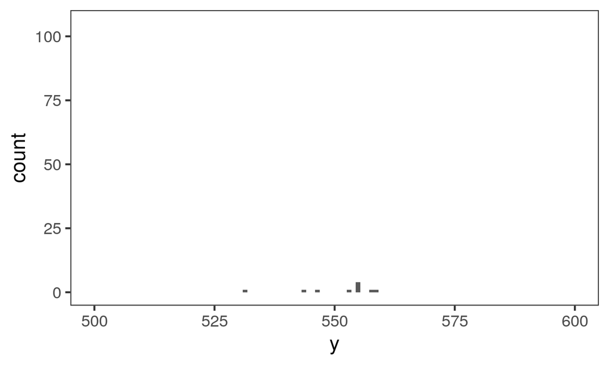

## Simulation of normal distributed data

- `rnorm` generates unimodal, symmetrically distributed values.
- `r` in `rnorm` = random; `norm` = normal

```r
# Generate data
y <- rnorm(n = 100, mean = 550, sd = 10)
```

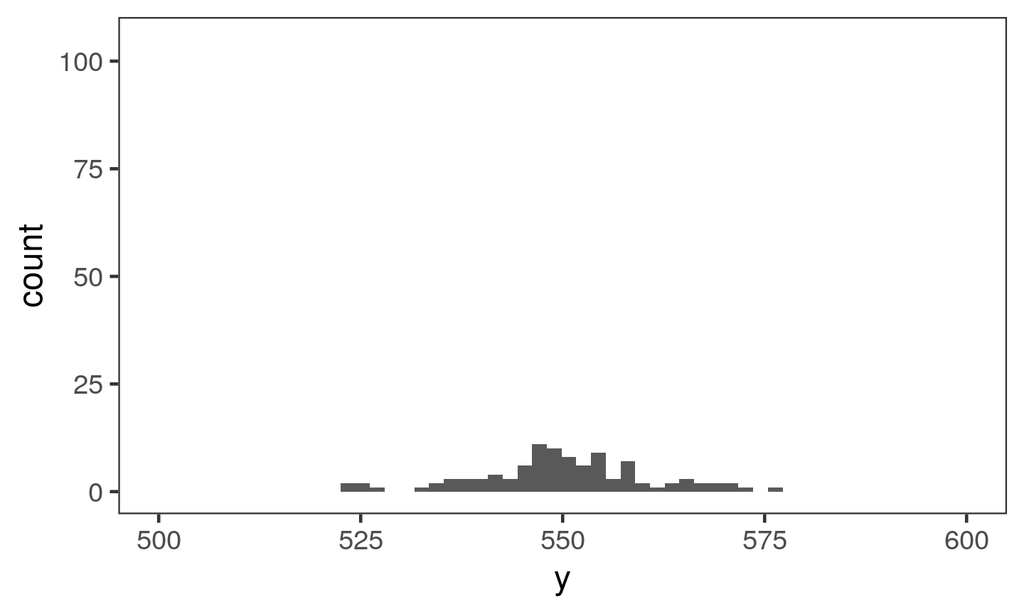

## Simulation of normal distributed data

- `rnorm` generates unimodal, symmetrically distributed values.
- `r` in `rnorm` = random; `norm` = normal

```r
# Generate data
y <- rnorm(n = 1000, mean = 550, sd = 10)
```

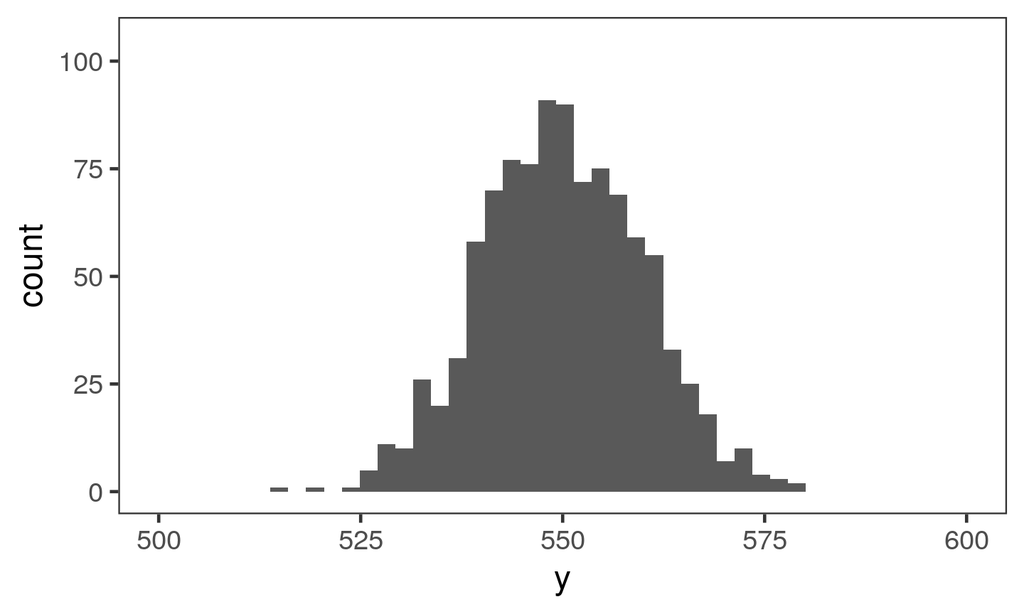

## Simulation of normal distributed data

- `rnorm` generates unimodal, symmetrically distributed values.
- `r` in `rnorm` = random; `norm` = normal

```r
# Decompose the mean
beta_0 = 500
beta_1 = 50
# Generate data
y <- rnorm(n = 1000, mean = beta_0 + beta_1, sd = 10)
```

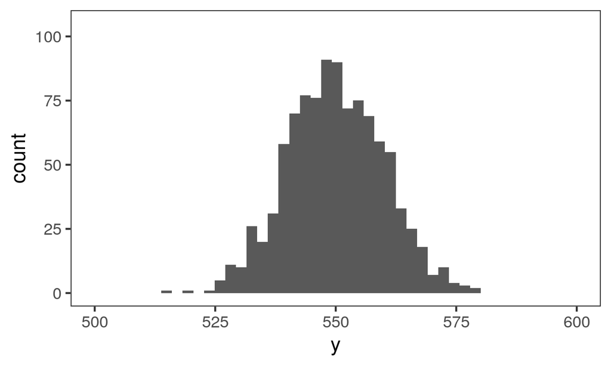

## Simulation of normal distributed data

```r
# Set parameter values
n <- 1000
beta_0 <- 500
beta_1 <- 50
sigma <- 100
```

```r
# Random data for group 1
group_1 <- rnorm(n = n/2, mean = beta_0, sd = sigma)
# Random data for group 2
group_2 <- rnorm(n = n/2, mean = beta_0 + beta_1, sd = sigma)
```

```r
# Generate data
sim_data <- tibble(group_1 = group_1,
                   group_2 = group_2)

# Preview data
glimpse(sim_data)
```

```
Rows: 500
Columns: 2
$ group_1 <dbl> 587, 478, 381, 472, 375, 316, 429, 580, 510, 387, 625, 456, 61…
$ group_2 <dbl> 631, 573, 475, 796, 634, 629, 571, 748, 726, 638, 394, 576, 60…
```

```r
# Change data format
sim_data <- pivot_longer(sim_data, cols = c(group_1, group_2), names_to = "x", values_to = "y")

# Preview data
glimpse(sim_data)
```

```
Rows: 1,000
Columns: 2
$ x <chr> "group_1", "group_2", "group_1", "group_2", "group_1", "group_2", "g…
$ y <dbl> 587, 631, 478, 573, 381, 475, 472, 796, 375, 634, 316, 629, 429, 571…
```

## Simulation of normal distributed data

```r
# As a reminder, these are the parameter values
beta_0 <- 500
beta_1 <- 50
sigma <- 100
```

```r
# Normal linear model of simulated data
model <- lm(y ~ x, data = sim_data)

coef(model) # Model coefficients
```

```
(Intercept)    xgroup_2
        504          54
```

```r
sigma(model) # Standard deviation
```

```
[1] 100
```

## Simulation: exercise

> Work through the scripts
- `exercises/normal_model_simulation_1.R`
- `exercises/normal_model_simulation_2.R`

> You will need to complete the code in those scripts. Then observe how changing the number of observations affects the model estimates.

## Real data

- In real life we don’t know the true parameter values.
- We also don’t know the true process that generates the data.
- For the simulated data we know that the process:
  - a normal distribution because `rnorm` samples normally distributed data
  - both groups have the same (equal) variance because the value for `sigma` was the same.
- We can use linear models to estimate parameter values from the data (i.e. we make assumptions about the process that generates the data).
- Maximum likelihood estimation: for which set of parameter values are the data most likely.

## Real data

- Data may appear non-normal distributed because of small sample.
- That’s fine if we know that a normal distribution underlies the process that generates the data.

```r
blomkvist <- read_csv("../data/blomkvist.csv") %>%
  select(id, sex, rt = rt_hand_d) %>%
  mutate(logrt = log(rt))
```

```
Rows: 267
Columns: 4
$ id    <dbl> 1, 2, 3, 4, 5, 6, 7, 8, 9, 10, 11,…
$ sex   <chr> "male", "female", "female", "femal…
$ rt    <dbl> 702, 471, 639, 708, 607, 542, 571,…
$ logrt <dbl> 6.55, 6.15, 6.46, 6.56, 6.41, 6.29…
```

- Above data are by-participant means, meaning the central limit theorem applies.
- Yet, reaction times are notoriously skewed (they are zero bound; see Baayen 2008).

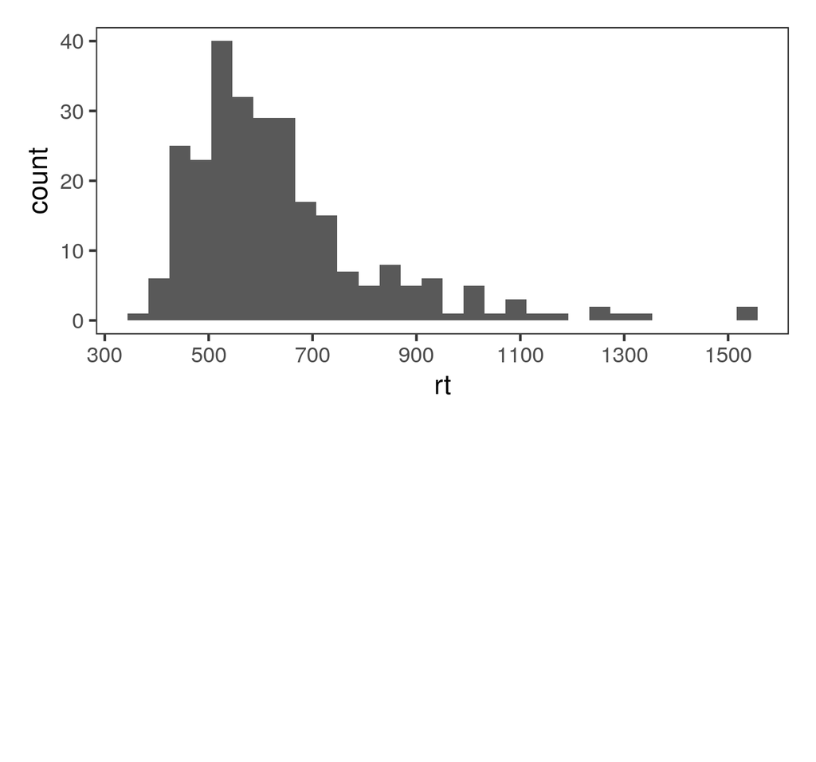

## Real data

- Data may appear non-normal distributed because of small sample.
- That’s fine if we know that a normal distribution underlies the process that generates the data.

```r
blomkvist <- read_csv("../data/blomkvist.csv") %>%
  select(id, sex, rt = rt_hand_d) %>%
  mutate(logrt = log(rt))
```

```
Rows: 267
Columns: 4
$ id    <dbl> 1, 2, 3, 4, 5, 6, 7, 8, 9, 10, 11,…
$ sex   <chr> "male", "female", "female", "femal…
$ rt    <dbl> 702, 471, 639, 708, 607, 542, 571,…
$ logrt <dbl> 6.55, 6.15, 6.46, 6.56, 6.41, 6.29…
```

- Above data are by-participant means, meaning the central limit theorem applies.
- Yet, reaction times are notoriously skewed (they are zero bound; see Baayen 2008).

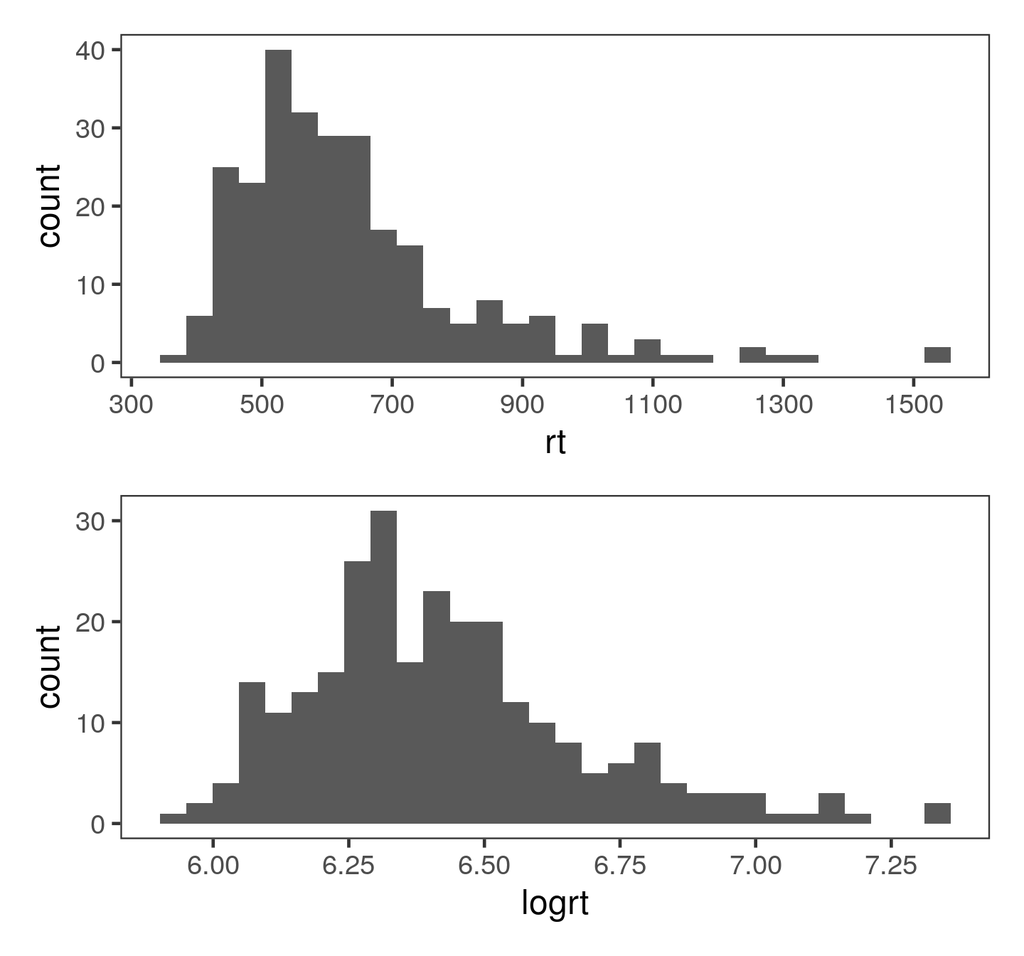

## Real data

\[ \text{logrt}_i \sim \mathcal{N}(\mu_i, \sigma^2) \]

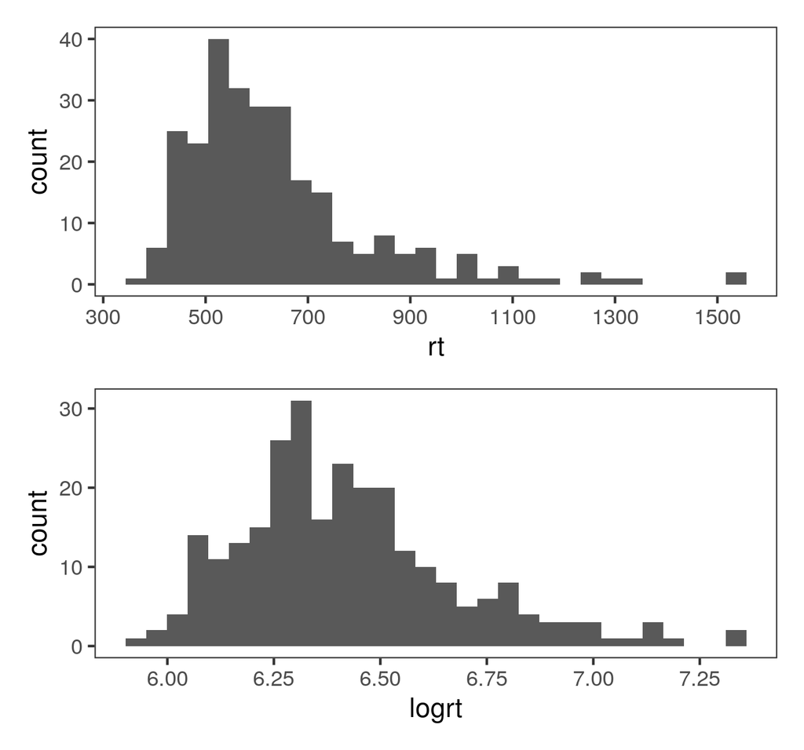

## Real data

> Predictor variable sex is denoted as \(\text{sex}_1, \text{sex}_2, \dots \text{sex}_n\), \(\text{ for } i \in 1\dots n\)

\[ \text{logrt}_i \sim \mathcal{N}(\mu_i, \sigma^2)\\ \mu_i = \beta_0 + \beta_\text{sex} \cdot \text{sex}_i \]

> where \(\text{sex}_i\) takes on \(0\) for females and \(1\) for males.

\[ \text{sex}_i = \left\{ \begin{array}{ll} 0, \text{ if sex}_i = \texttt{female}\\ 1, \text{ if sex}_i = \texttt{male}\\ \end{array} \right. \]

> variance is the same in males and females.

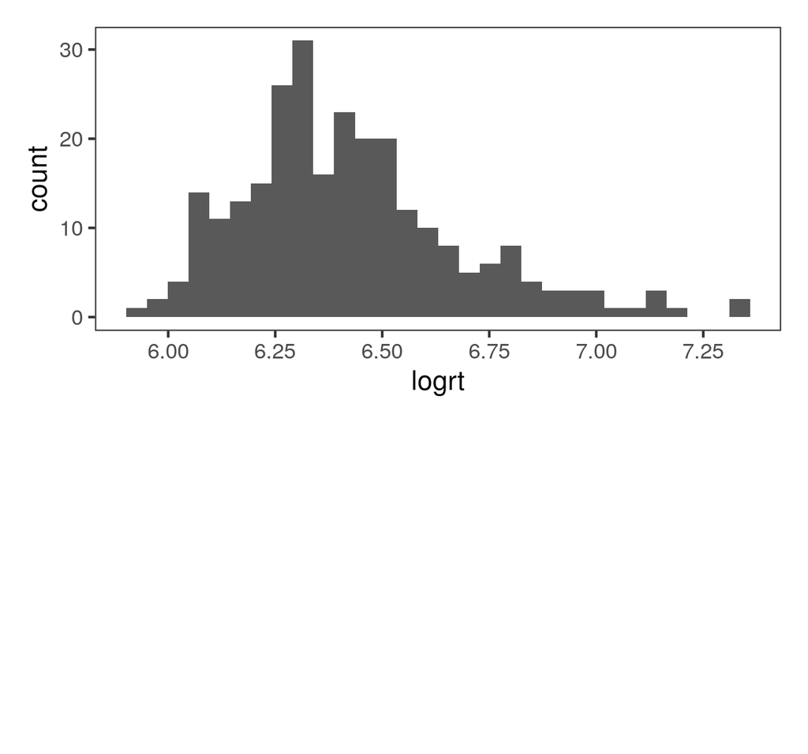

## Real data

> Predictor variable sex is denoted as \(\text{sex}_1, \text{sex}_2, \dots \text{sex}_n\), \(\text{ for } i \in 1\dots n\)

\[ \text{logrt}_i \sim \mathcal{N}(\mu_i, \sigma^2)\\ \mu_i = \beta_0 + \beta_\text{sex} \cdot \text{sex}_i \]

> where \(\text{sex}_i\) takes on \(0\) for females and \(1\) for males.

\[ \text{sex}_i = \left\{ \begin{array}{ll} 0, \text{ if sex}_i = \texttt{female}\\ 1, \text{ if sex}_i = \texttt{male}\\ \end{array} \right. \]

> variance is the same in males and females.

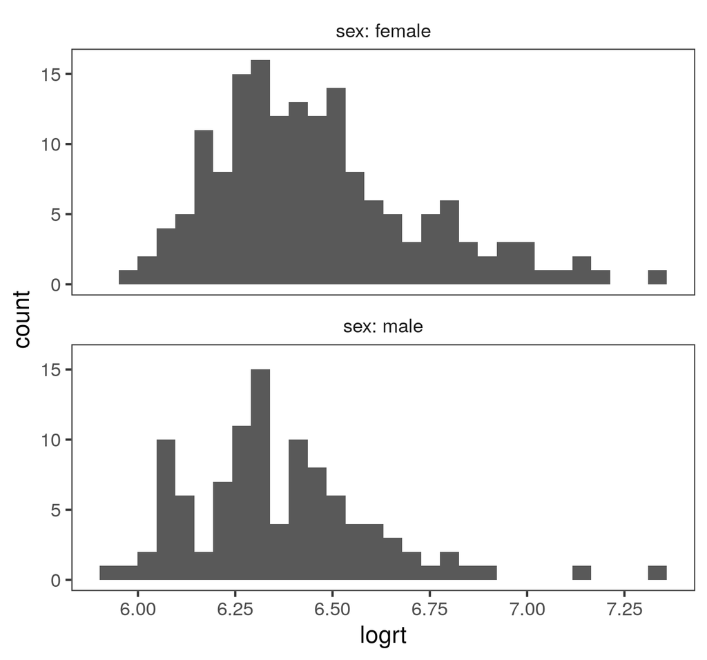

## Real data

> Predictor variable sex is denoted as \(\text{sex}_1, \text{sex}_2, \dots \text{sex}_n\), \(\text{ for } i \in 1\dots n\)

\[ \text{logrt}_i \sim \mathcal{N}(\mu_i, \sigma^2)\\ \mu_i = \beta_0 + \beta_\text{sex} \cdot \text{sex}_i \]

> where \(\text{sex}_i\) takes on \(0\) for females and \(1\) for males.

\[ \text{sex}_i = \left\{ \begin{array}{ll} 0, \text{ if sex}_i = \texttt{female}\\ 1, \text{ if sex}_i = \texttt{male}\\ \end{array} \right. \]

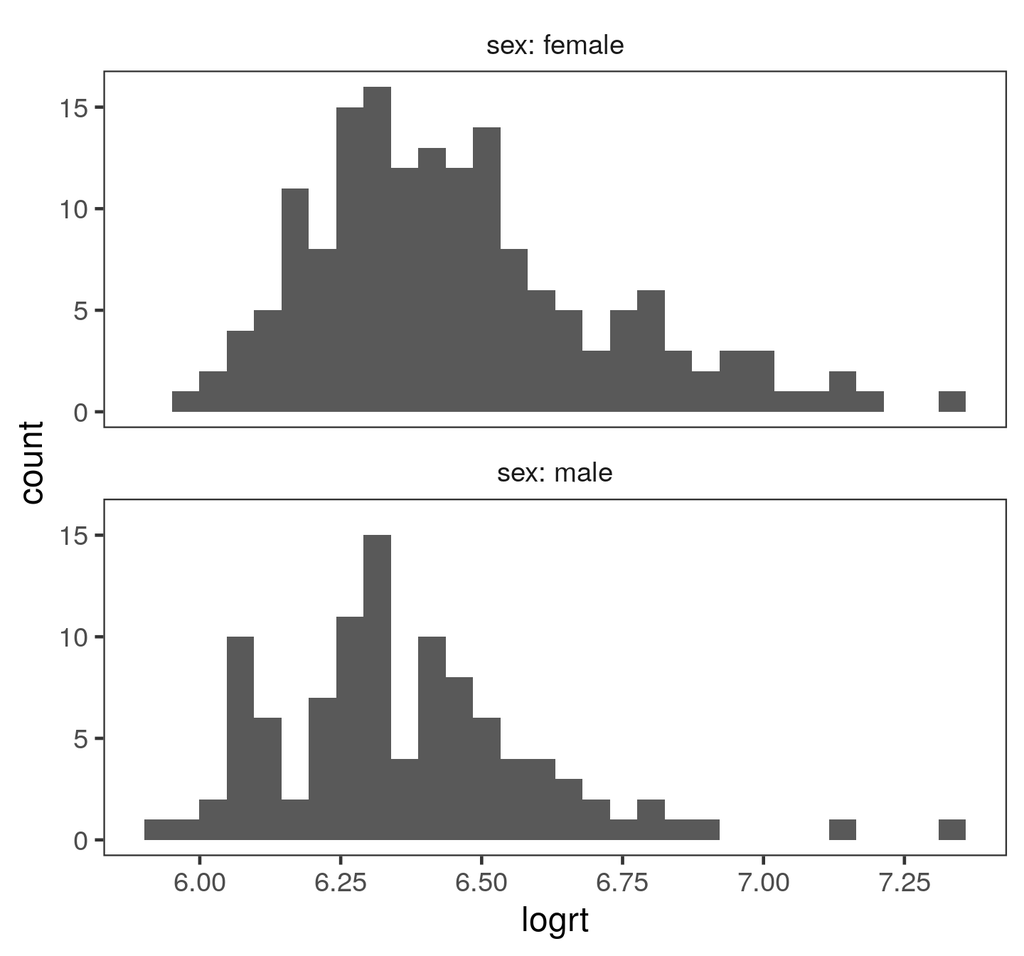

## Real data: exercise

- Complete exercise scripts
  - `exercises/normal_model_blomkvist_1.R`
  - `exercises/normal_model_blomkvist_2.R`
- Make sure you understand how the model coefficients relate to the visualisation.

## Compare simulated and real data

```r
# Set parameter values
beta_0 <- 500
beta_1 <- 50
sigma <- 100
```

```r
# Inspect data
glimpse(data, width = 50)
```

```
Rows: 1,000
Columns: 2
$ x <chr> "group_1", "group_2", "group_1", "grou…
$ y <dbl> 530, 393, 322, 597, 433, 691, 579, 483…
```

```r
# Specify model
model <- lm(y ~ x, data = data)
```

```r
# Model coefficients
coef(model)
```

```
(Intercept)    xgroup_2
      494.9        57.6
```

```r
# Load and transform data
blomkvist <- read_csv("../data/blomkvist.csv") %>%
  mutate(log_rt = log(rt_hand_d)) %>%
  select(sex, log_rt)
```

```r
# Inspect data
glimpse(blomkvist, width = 50)
```

```
Rows: 267
Columns: 2
$ sex    <chr> "male", "female", "female", "fema…
$ log_rt <dbl> 6.55, 6.15, 6.46, 6.56, 6.41, 6.2…
```

```r
# Specify model
model <- lm(log_rt ~ sex, data = blomkvist)
```

```r
# Model coefficients
coef(model)
```

```
(Intercept)     sexmale
     6.4602     -0.0943
```

## Interpreting coeffcients on the log scale

> Slope coef is no longer additive (linear scale) but multiplicative (exponential scale)

```r
# Specify model
model <- lm(log_rt ~ sex, data = blomkvist)

# Model coefficients
(coefs <- as.vector(coef(model)))
```

```
[1]  6.4602 -0.0943
```

> I.e. `logrt` is \(\beta_1\) times longer.

```r
# Converting coefficients to msecs
intercept <- coefs[1]
slope <- coefs[2]
```

> Exponentional function `exp` un-logs coefficients.

```r
exp(intercept) # female group in msecs
```

```
[1] 639
```

```r
exp(intercept + slope) # male group in msecs
```

```
[1] 582
```

```r
exp(intercept + slope) - exp(intercept) # in msecs
```

```
[1] -57.5
```

Complete

- `exercises/interpreting_coefficients_1.R`
- `exercises/interpreting_coefficients_2.R`

## Maximum likelihood estimation

> If we assume the model

\[ y_i \sim \mathcal{N}(\mu_i, \sigma^2) \text{, for } i \in 1\dots n\\ \mu_i = \beta_0 + \sum_{k=1}^K \beta_k \cdot x_{ki} \]

> how can we estimate values of \(K+2\) unknowns.

> The maximum likelihood estimators of the \(K + 2\) unknowns, which we can denote by

\[ \hat\beta_0,\hat\beta_1\dots\hat\beta_K,\hat\sigma, \]

> are the set of values that make the observed data most probable.

## Maximum likelihood estimation

> The maximum likelihood values of coefficients \(\hat\beta_0,\hat\beta_1\dots\hat\beta_K\) are those values of \(\beta_0,\beta_1\dots\beta_K\) variables that minimize *residual sum of squares*

\[ \text{RSS} = \sum_{i=1}^n \mid y_i - \mu_i\mid^2, \]

> where \(\mu_i\) is (as before)

\[ \mu_i = \beta_0 + \sum_{k=1}^K \beta_k \cdot x_{ki} \]

> This can be simulated using grid approximation for models with small sets of unknowns: see script `exercises/mle.R`

## Fitting a normal linear model using `lm`

- For larger sets of parameters we can use maximum likelihood estimation as implemented in `lm`.
- We’ll continue with the Blomkvist et al. (2017) `rt` data for simplicity.

```r
model <- lm(rt ~ sex + age, data = blomkvist)
```

- Maximum likelihood estimators of \(\beta_0\), \(\beta_\text{sex}\) and \(\beta_\text{age}\) are as follow:

```r
(coefs <- coef(model))
```

```
(Intercept)     sexmale         age
     338.64      -58.93        5.75
```

## Fitting a normal linear model using `lm`

> Once we have \(\hat\mu\), the maximum likelihood estimate of \(\sigma\), denoted as \(\hat\sigma\), is:

\[ \hat\sigma = \sqrt{\frac{1}{n-K-1} \cdot \sum_{i=1}^n\mid y_i-\hat\mu_i\mid^2} \]

- \(\sum_{i=1}^n\mid y_i-\hat\mu_i\mid^2\) is the RSS (\(y_i\): observed data; \(\hat\mu_i\): model prediction).
- \(K\) is the number of predictors
- \(n\) is the number of observations
- Complete script `exercises/calculating_sigma.R`

## Hypothesis testing: *t*-values

> If \(\beta_k\) is the **hypothesized** true value of the coefficient, and \(\hat\beta_k\) is the estimated coefficient, then

\[ \frac{\hat\beta_k - \beta_k}{\hat{\text{se}}_k} \sim t_{n-K-1}, \]

> which tells us that if the true value of the coefficient was some hypothesized value \(\beta_k\), then we expect the *t*-statistic to have a certain range of values with high probability.

## Hypothesis testing: *t*-values

> We will test a hypothesis about the coefficient for sex in the model above.

```r
# Extract the coefficients table from summary
coefs <- summary(model)$coefficients
# MLE for sex
(beta_sex <- coefs['sexmale', 'Estimate'])
```

```
[1] -58.9
```

```r
# Standard error
(se_sex <- coefs['sexmale', 'Std. Error'])
```

```
[1] 18.5
```

> If we hypothesize the true value of the coefficient is exactly 1.0, then our *t*-statistic is

```r
(t <- (beta_sex - 1.0)/se_sex)
```

```
[1] -3.24
```

\[ \frac{\hat\beta_k - \beta_k}{\hat{\text{se}}_k} = \frac{-58.9 - 1.0}{18.5} = -3.24 \]

## *p*-values

- The *p*-value for the hypothesis is the probability of getting a value *as or more extreme* than the absolute value of *t*-statistic in the *t*-distribution.
- This is the area under the curve in the *t*-distribution that is as or more extreme than the absolute value of *t*-statistic.

```r
n <- nrow(blomkvist)
K <- 2
pt(abs(t), df = n - K - 1, lower.tail = FALSE) * 2
```

```
[1] 0.00133
```

## Hypothesis testing: *t*-values

> **Null hypothesis significance testing**: we hypothesize the true value of the coefficient is exactly 0.0, then our *t*-statistic is

\[ \frac{\hat\beta_k - \beta_k}{\hat{\text{se}}_k} = \frac{-58.9 - 0.0}{18.5} = \frac{-58.9}{18.5} = -3.19 \]

```r
(t <- (beta_sex - 0.0)/se_sex)
```

```
[1] -3.19
```

```r
n <- nrow(blomkvist)
K <- 2
pt(abs(t), df = n - K - 1, lower.tail = FALSE) * 2
```

```
[1] 0.00159
```

## *p*-values

- Work through script `exercise/t_values.R`
- Calculate *t* and *p*-value for \(\hat\beta_\text{age}\) testing the null hypothesis that the true value \(\beta_\text{age}\) is 0.0.
- Verify your calculation using

```r
summary(model)$coefficients
```

```
            Estimate Std. Error t value Pr(>|t|)
(Intercept)   338.64     27.359   12.38 4.91e-28
sexmale       -58.93     18.473   -3.19 1.59e-03
age             5.75      0.439   13.09 1.72e-30
```

## *t*-distribution

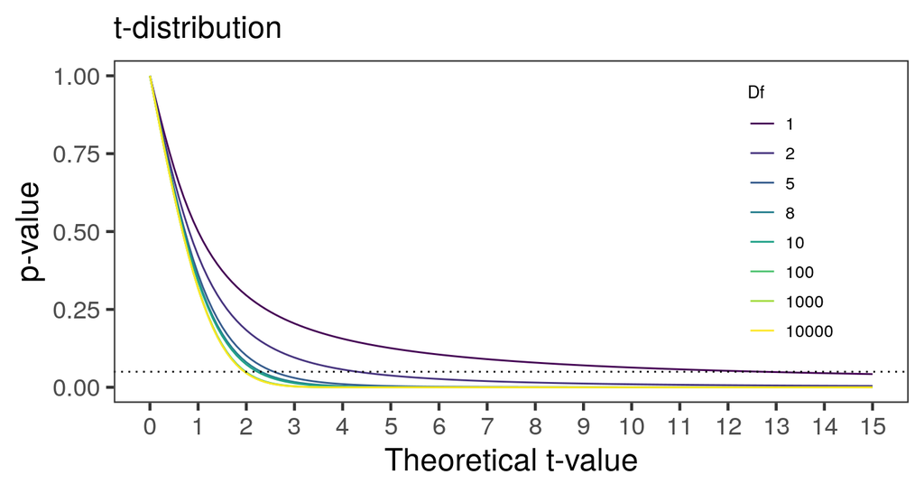

## *t*-distribution

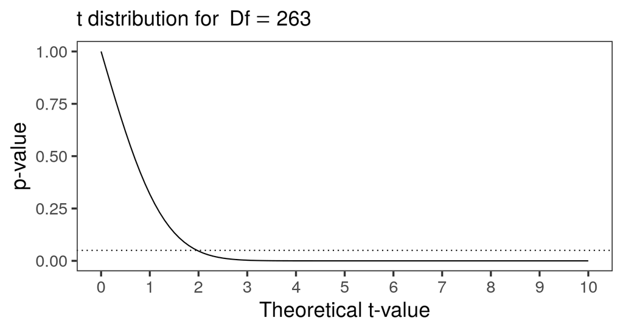

## *t*-distribution

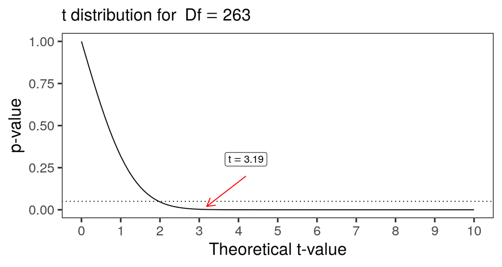

## *t*-distribution

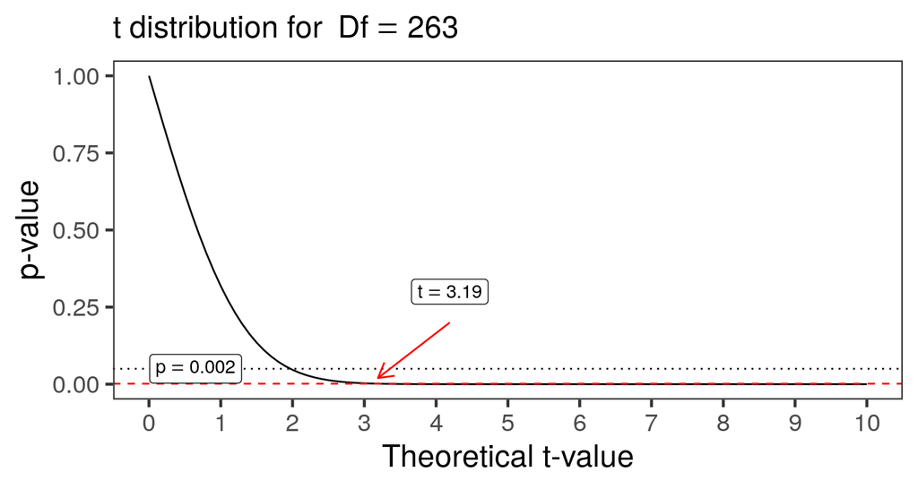

## *t*-distribution

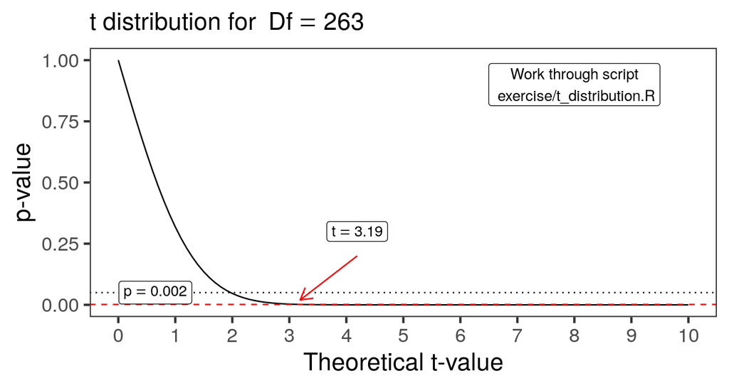

## Confidence intervals

- The set of all hypotheses (hypothetical values) that we do not rule out at the \(\alpha < 0.05\) level of significance is known as the 95% confidence interval.
- The formula for the confidence interval on coefficient \(k\) is

\[ 95\% \text{ CI} = \hat\beta_k \pm \tau_\nu \cdot \hat{\text{se}}_k \]

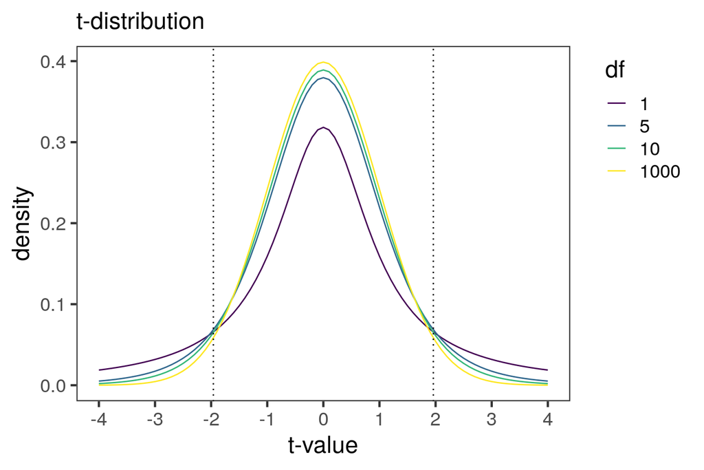

## Confidence intervals

```r
(coefs <- coef(summary(model)))
```

```
            Estimate Std. Error t value Pr(>|t|)
(Intercept)   338.64     27.359   12.38 4.91e-28
sexmale       -58.93     18.473   -3.19 1.59e-03
age             5.75      0.439   13.09 1.72e-30
```

```r
beta_sex <- coefs[2,1]
se_sex <- coefs[2,2]
```

> We can calculate \(\tau\) using `qt`

```r
(tau <- qt(.975, df = n - K - 1))
```

```
[1] 1.97
```

> We then obtain the confidence intervals as follows

```r
beta_sex + c(-1, 1) * se_sex * tau
```

```
[1] -95.3 -22.6
```

```r
confint(model, parm = 'sexmale',  level = .95)
```

```
        2.5 % 97.5 %
sexmale -95.3  -22.6
```

> Open and complete script `exercises/confidence_interval.R`

## Confidence intervals: a simulation

- Work through script `exercises/confidence_interval_simulation.R`
- Change the number of simulations to, one at a time, `n_sims = 20, 50, 100, 500, 1000`
- Notice how often the CI does not contain the true parameter value \(\mu\).
- How many % of simulations contain \(\mu\)?

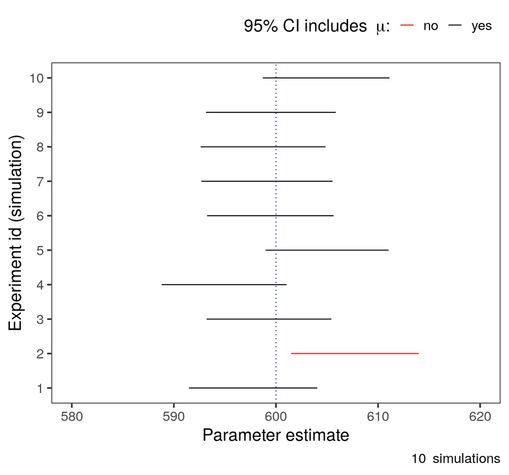

## Confidence intervals: a simulation

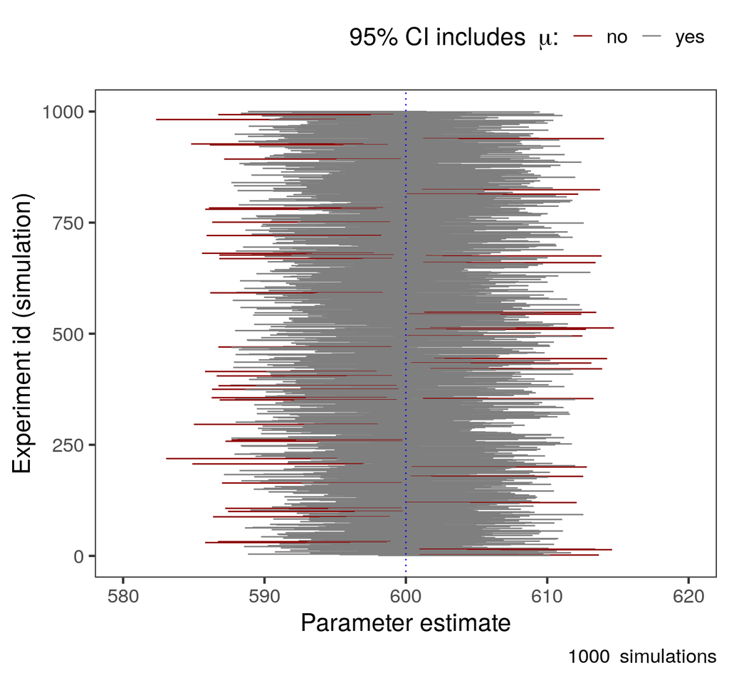

```r
count(sims, mu_in_ci) %>%
  mutate(prop = n / n_sims)
```

```
# A tibble: 2 × 3
  mu_in_ci     n  prop
  <chr>    <int> <dbl>
1 no          51 0.051
2 yes        949 0.949
```

- When number of experiments approaches \(\infty\) and we calculate the 95% CI for each experiment, 95% of these CIs contain \(\mu\).
- Note though, 5% of the time, the confidence interval does not contain \(\mu\)!
- What does this mean for real (as opposed to simulated) experiments?

## Predictions

> Using \(\hat\beta_0,\hat\beta_1\dots\hat\beta_K\) and \(\hat\sigma^2\), then for any new vector of predictor variables \(\overrightarrow{x}_{i'}\), the corresponding \(y_i\) is

\[ y_{i'} \sim \mathcal{N}(\hat\mu_{i'}, \sigma^2)\\ \hat\mu_{i'} = \hat\beta_0 + \sum_{k=1}^K \hat\beta_k \cdot x_{i'k} \]

## Predictions

```
(Intercept)     sexmale         age
     338.64      -58.93        5.75
```

> For \(K = 2\) we can predict rts for a hypothetical female age 95.

\[ \begin{aligned} \hat\mu_i &= \hat\beta_0 + \hat\beta_\text{sex} \cdot \text{sex}_{i} + \hat\beta_\text{age} \cdot \text{age}_{i}\\ &=338.64 + -58.93 \cdot \text{sex}_{i} + 5.75 \cdot \text{age}_{i}\\ &=338.64 + -58.93 \cdot 0 + 5.75 \cdot 95\\ &=338.64 + 5.75 \cdot 95\\ &=885 \end{aligned} \]

> To calculate \(\hat\mu_{i'}\) for any vector of predictor variables \(\overrightarrow{x}_{i'}\)

```r
newdata <- tibble(sex = "female", age = 95)
predict(model, newdata = newdata)
```

```
  1
885
```

## Prediction confidence intervals

- We can calculate confidence intervals for the predicted values of \(\mu_{i'}\).
- The confidence interval for \(\mu_{i'}\) is as follows:

\[ \hat\mu_{i'} \pm \tau_\nu \cdot \hat{\text{se}}_{\mu_{i'}} \]

> where \(\hat{\text{se}}_{\mu_{i'}}\) is the standard error term that corresponds to \(\hat\mu_{i'}\).
- We can obtain these by using `interval = 'confidence'` in the `predict` function.

```r
predict(model, interval = 'confidence', newdata = newdata)
```

```
  fit lwr upr
1 885 845 925
```

## Prediction confidence intervals: exercise

> Work through scripts
- `exercises/predictions.R`
- `exercises/predictions_with_cis.R`

## Varying intercepts model

> When we include `sex` as an explanatory variable in additional to a continuous predictor variable (e.g. `age`), the model is as follows.

\[ \text{rt}_i \sim \mathcal{N}(\mu_i, \sigma^2)\\ \mu_i = \beta_0 + \beta_\text{sex} \cdot \text{sex}_{i} + \beta_\text{age} \cdot \text{age}_{i} \]

> With sexes denoted by \(\text{sex}_{1},x_{2}\dots \text{sex}_{i}\dots \text{sex}_{n}\) and age by \(\text{age}_{1},\text{age}_{2}\dots \text{age}_{i}\dots \text{age}_{n}\) \(\text{ for } i \in 1\dots n\).

## Varying intercepts model

> To implement this model using `lm` we would do the following.

```r
model_2 <- lm(rt ~ sex + age, data = blomkvist)
coef(model_2)
```

```
(Intercept)     sexmale         age
     338.64      -58.93        5.75
```

- Note that `sex` is dichotomous categorical and `age` is continuous.
- Normal distribution over `rt` for any given combination of sex and age.
- If `sex` changes by one unit, when age is held constant, then the average value of the corresponding distribution of `rt` changes by \(\beta_\text{sex}\).
- Conversely, if `age` changes by one unit, when `sex` is held constant, the average value of the distribution of `rt` changes by \(\beta_\text{age}\).

## Varying intercepts model

> Given that \(\text{sex}_{i}\) takes that value of 0 when `sex` is female and 1 when `sex` is male, this model can be written as follows.

\[ \text{rt}_i \sim \mathcal{N}(\mu_i, \sigma^2) \\ \mu_i = \beta_0 + \beta_\text{sex} \cdot \text{sex}_{i} + \beta_\text{age} \cdot \text{age}_{i}\\ \mu_i = \left\{ \begin{array}{ll} \beta_0 + \beta_\text{age} \cdot \text{age}_{i}, \text{ if sex}_i = 0 \texttt{ [female]}\\ \beta_0 + \beta_\text{sex} \cdot \text{sex}_{i} + \beta_\text{age} \cdot \text{age}_{i}, \text{ if sex}_i = 1\texttt{ [male]} \end{array} \right. \]

> This is a *varying intercepts* model.

## Varying intercepts model

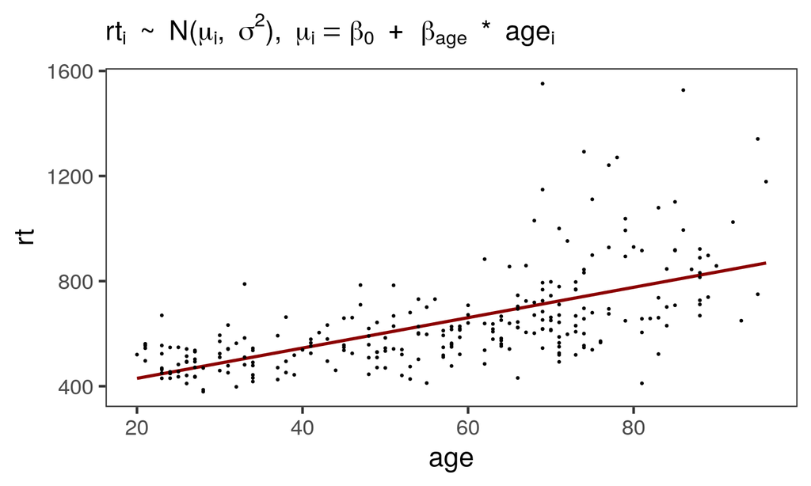

## Varying intercepts model

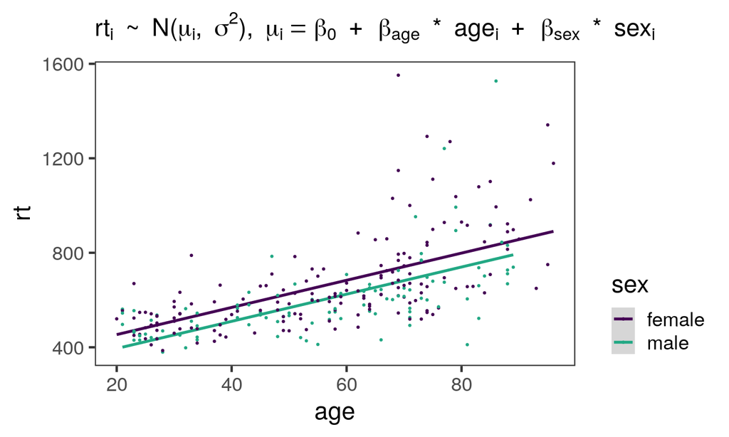

## Varying intercepts and varying slopes model

The varying-intercepts model is written as follows. For \(i \in 1\dots n\)

\[ \begin{aligned} \text{rt}_i &\sim N(\mu_i, \sigma^2)\\ \mu_i &= \beta_0 + \beta_\text{sex} \cdot \text{sex}_{i} + \beta_\text{age} \cdot \text{sex}_{i}\\ \end{aligned} \]

The following is a varying intercepts and varying slopes model:

\[ \begin{aligned} \text{rt}_i &\sim N(\mu_i, \sigma^2)\\ \mu_i &= \beta_0 + \beta_\text{sex} \cdot \text{sex}_{i} + \beta_\text{age} \cdot \text{age}_{i} + \underbrace{\beta_\text{sex,age} \cdot \text{sex}_{i} \cdot \text{age}_{i}}_\text{interaction} \end{aligned} \]

We effectively have a third predictor that is the product of \(\text{sex}_{i} \cdot \text{age}_{i}\); i.e. the interaction.

## Varying intercepts and varying slopes model

Using `sex` and `age` as predictors, we can do the following to perform a varying-intercepts and varying-slopes model:

```r
model_3 <- lm(rt ~ sex + age + sex:age, data = blomkvist)
```

Or slightly shorter:

```r
model_3 <- lm(rt ~ sex * age, data = blomkvist)
```

## Varying intercepts and varying slopes model

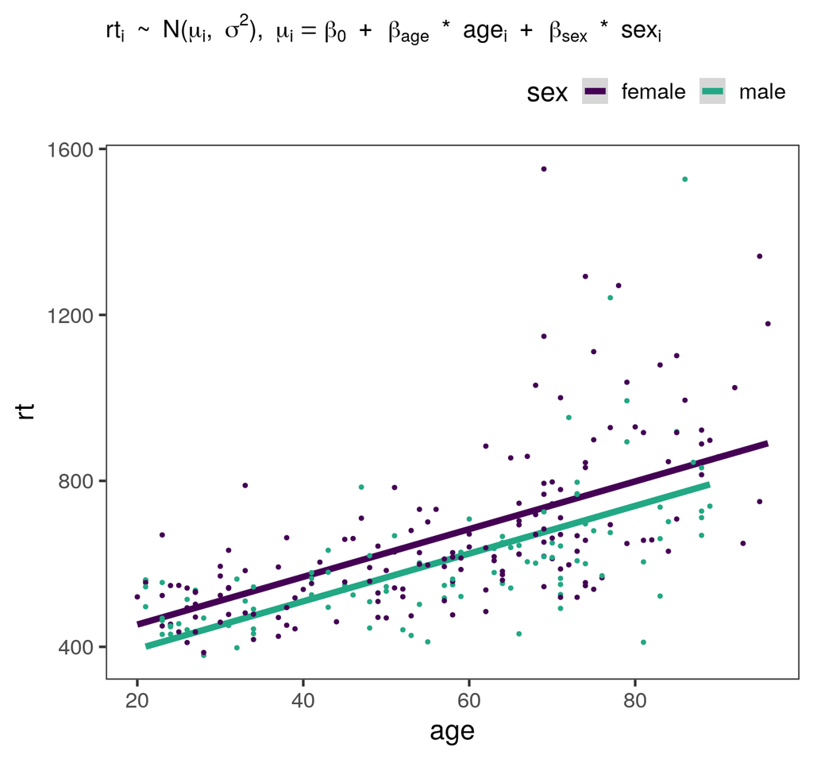

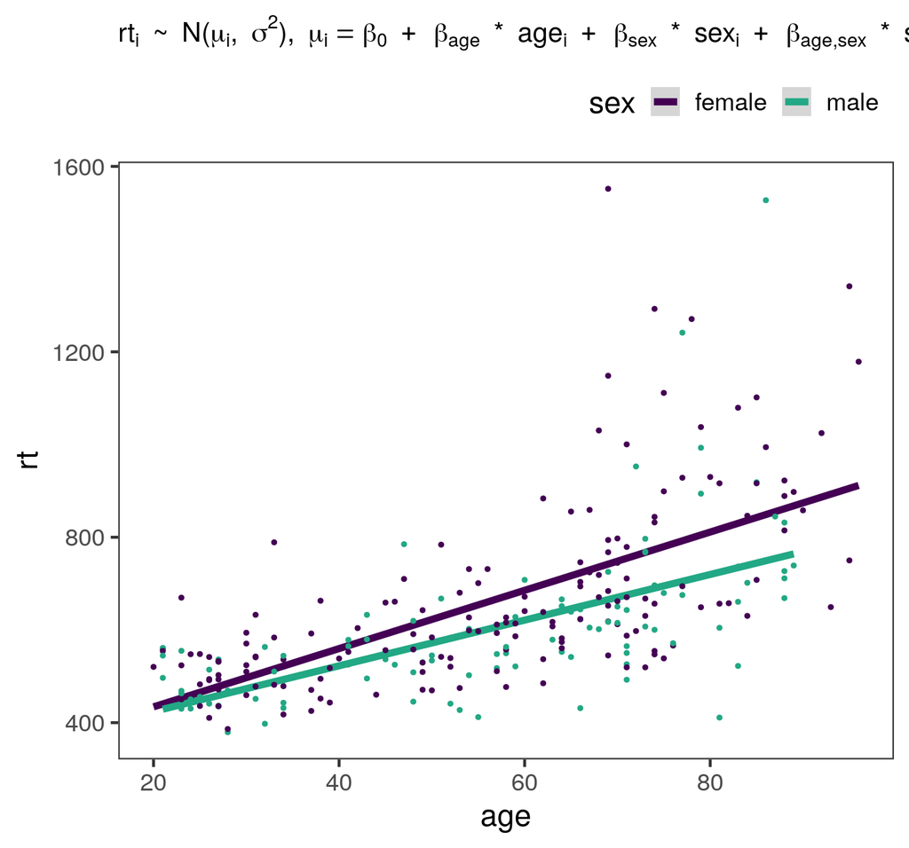

## Varying intercepts and varying slopes model

> From the varying-intercepts and varying-slopes model, the intercept terms for `female` and `male` are

```r
model_3 <- lm(rt ~ sex * age, data = blomkvist)
```

```r
(betas <- coef(model_3))
```

```
(Intercept)     sexmale         age sexmale:age
     308.46       17.15        6.28       -1.36
```

```r
# females
betas[1]
```

```
[1] 308
```

```r
# males
betas[1] + betas[2]
```

```
[1] 326
```

> The slope terms are as follows:

```r
# females
betas[3]
```

```
[1] 6.28
```

```r
# males
betas[3] + betas[4]
```

```
[1] 4.93
```

## Varying intercepts and varying slopes model

> From the varying-intercepts and varying-slopes model, the intercept terms for `female` and `male` are

```r
model_3 <- lm(rt ~ sex * age, data = blomkvist)
```

```r
(betas <- coef(model_3))
```

```
(Intercept)     sexmale         age sexmale:age
     308.46       17.15        6.28       -1.36
```

```r
# females
betas[1]
```

```
[1] 308
```

```r
# males
betas[1] + betas[2]
```

```
[1] 326
```

> The slope terms are as follows:

```r
# age slope for females
betas[3]
```

```
[1] 6.28
```

```r
# age slope for males
betas[3] + betas[4]
```

```
[1] 4.93
```

```r
# sex difference for age slopes
betas[4]
```

```
[1] -1.36
```

## Varying intercepts and varying slopes model

> Work through scripts
- `exercises/varying_intercepts_model.R`
- `exercises/varying_slopes_model.R`

## Polychotomous predictors

> Using `smoker` as single categorical predictor variable, the linear model would be as follows.

\[ \text{rt}_i \sim N(\mu_i, \sigma^2), \mu_i = \beta_0 + \beta_\text{smoker[1]} \cdot \text{smoker}_{1i} + \beta_\text{smoker[2]} \cdot \text{smoker}_{2i}, \text{ for } i \in 1\dots n. \]

> where \(\text{smoker}_{1i}\), \(\text{smoker}_{2i}\) are as follows.

\[ \text{smoker}_{1i}, \text{smoker}_{2i} = \left\{ \begin{array}{ll} 0,0 \text{ if smoker}_i = \texttt{former}\\ 1,0 \text{ if smoker}_i = \texttt{no}\\ 0,1 \text{ if smoker}_i = \texttt{yes}\\ \end{array} \right. \]

> The number of coefs for predictor is \(K-1\) where \(K\) is number of levels of the predictor.

```r
# Categories of smoker
levels(blomkvist$smoker) #  3 levels
```

```
[1] "former" "no"     "yes"
```

## Polychotomous predictors

> Using `lm`, we would simply do as follows.

```r
model_smoker <- lm(rt ~ smoker, data = blomkvist)
(betas <- coef(model_smoker))
```

```
(Intercept)    smokerno   smokeryes
      652.5       -18.0       -19.1
```

> Default contrasts for polychotomous predictor used by `lm`.

```r
contrasts(blomkvist$smoker)
```

```
       no yes
former  0   0
no      1   0
yes     0   1
```

> The intercept term is the predicted average when `smoker` is `former` (i.e. row with only 0s).

## Polychotomous predictors

> Using `lm`, we would simply do as follows.

```r
model_smoker <- lm(rt ~ smoker, data = blomkvist)
(betas <- coef(model_smoker))
```

```
(Intercept)    smokerno   smokeryes
      652.5       -18.0       -19.1
```

> The predicted mean of the rt distribution for `no`

\[ \hat\beta_0 + \hat\beta_1 \cdot 1 + \hat\beta_2 \cdot 0 \]

```r
betas[1] + betas[2] * 1 + betas[3] * 0
```

```
[1] 635
```

## Polychotomous predictors

> Using `lm`, we would simply do as follows.

```r
model_smoker <- lm(rt ~ smoker, data = blomkvist)
(betas <- coef(model_smoker))
```

```
(Intercept)    smokerno   smokeryes
      652.5       -18.0       -19.1
```

> When `smoker` is `yes`, the predicted mean of the rt distribution for smokers is

\[ \hat\beta_0 + \hat\beta_1 \cdot 0 + \hat\beta_2 \cdot 1 \]

```r
betas[1] + betas[2] * 0 + betas[3] * 1
```

```
[1] 633
```

> Exercise: work through script `exercises/polychotomous_predictor.R`

## Contrast coding

> Change contrast coding so intercept represents the average across both groups and to get desired copmarisons (for discussion see Schad et al. 2020; Brehm and Alday 2022).

```r
coef(model_smoker)
```

```
(Intercept)    smokerno   smokeryes
      652.5       -18.0       -19.1
```

```r
# Default: treatment contrast
contrasts(blomkvist$smoker)
```

```
       no yes
former  0   0
no      1   0
yes     0   1
```

```r
contr.treatment(3, base = 2) # change base level
```

```
       former yes
former      1   0
no          0   0
yes         0   1
```

```r
contr.helmert(3) / 2 # Helmert contrast
```

```
       former vs no former / no vs yes
former         -0.5               -0.5
no              0.5               -0.5
yes             0.0                1.0
```

```r
contr.sum(3) / 2 # sum contrast
```

```
       former vs yes no vs yes
former           0.5       0.0
no               0.0       0.5
yes             -0.5      -0.5
```

```r
model <- lm(rt ~ smoker, data = blomkvist) # Re-fit model with sum contrast
coef(model)
```

```
        (Intercept) smokerformer vs yes     smokerno vs yes
              640.2                24.7               -11.2
```

```r
coef(model_smoker) # model with treatment contrasts
```

```
(Intercept)    smokerno   smokeryes
      652.5       -18.0       -19.1
```

> Exercise: work through script `exercises/contrast_coding.R`

## Recap

- Normal model assumes a single normal distributed data generating process.
- Log-normal transformation is often used to correct positive skew (assuming a log-normal process).
- MLE provides estimates for unknown population parameters.
- We can specify models with continues and / or categorical predictors.
- Combinatioins are varying intercepts and / or varying slopes.
- Read lecture notes on NOW (also Andrews 2021).
- Model comparisons: has age a stronger effect for females than for males?

## Homework

- We will start preparing your formative assessment next week.
- Review the [details for the formative assessment.](https://now.ntu.ac.uk/d2l/le/content/887088/viewContent/9653015/View)

> *Using a data-set of your own choice, perform and report a linear regression analysis to address a set of theoretical questions of your choice that relate to your chosen data-set*
- Find a suitable data set you can use for the formative assessment.
- Create an outline for your report (what do you need to include?).

## References

Andrews, Mark. 2021. *Doing Data Science in R: An Introduction for Social Scientists*. SAGE Publications Ltd.

Baayen, R. Harald. 2008. *Analyzing Linguistic Data. A Practical Introduction to Statistics Using R*. Cambridge: Cambridge University Press.

Blomkvist, Andreas W., Fredrik Eika, Martin T. Rahbek, Karin D. Eikhof, Mette D. Hansen, Malene Søndergaard, Jesper Ryg, Stig Andersen, and Martin G. Jørgensen. 2017. “Reference Data on Reaction Time and Aging Using the Nintendo Wii Balance Board: A Cross-Sectional Study of 354 Subjects from 20 to 99 Years of Age.” *PLoS One* 12 (12): e0189598.

Brehm, Laurel, and Phillip M. Alday. 2022. “Contrast Coding Choices in a Decade of Mixed Models.” *Journal of Memory and Language* 125: 104334.

Schad, Daniel J., Shravan Vasishth, Sven Hohenstein, and Reinhold Kliegl. 2020. “How to Capitalize on a Priori Contrasts in Linear (Mixed) Models: A Tutorial.” *Journal of Memory and Language* 110: 104038.